# Data wrangling in tidyr

Kiran Favre

2022-08-15

## Data wrangling

#### Read in World Bank data files

```r
wb_indicators <- read_csv(here("data", "wb_indicators.csv"), na = c("..", ""))
# notice how empty values are populated by '..' and by empty cells! so we use na

wb_metadata <- read_csv(here("data", "wb_indicators_metadata.csv"))
```

#### How can we make this data more tidy?

##### Put all years in one column and seriesnames in one row

- can use pivotlonger to get years into a single column
  - start with data, then use function and think of which columns you want to gather together.

```r
wb_indicators_long <- wb_indicators |>
  pivot_longer(cols = '2001 [YR2001]': '2020 [YR2020]',
               names_to = "year",
               values_to = "indicator_value")
```

#### Separate to clean up year column

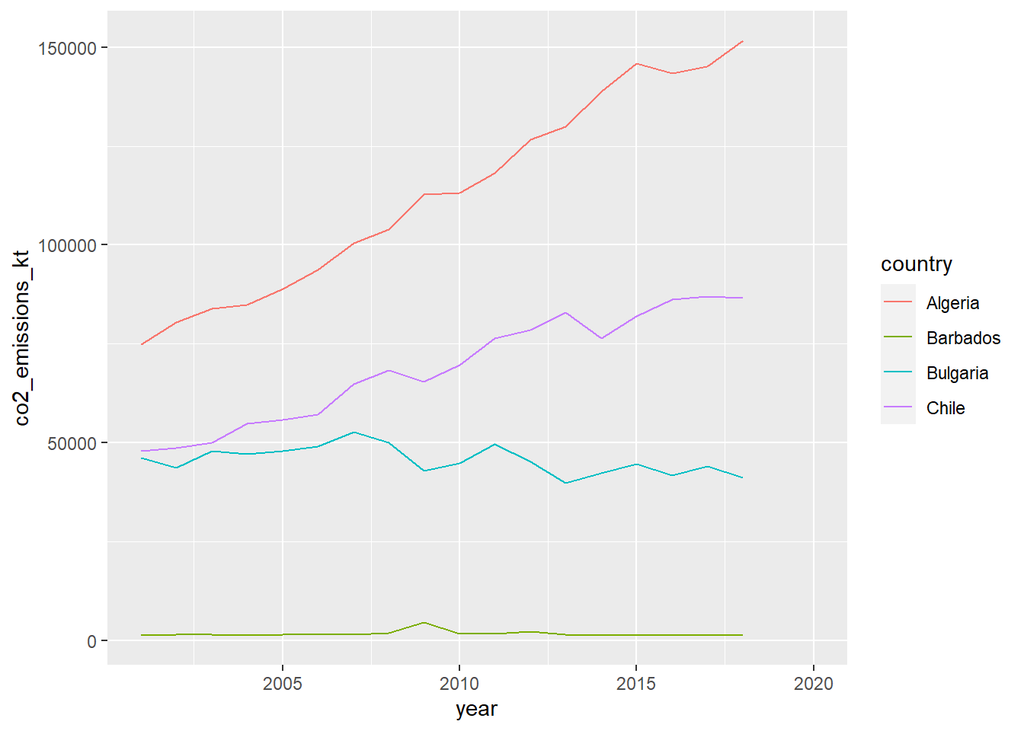

```r
wb_clean <- wb_indicators_long |>
  separate(col = year, into = c("year", "year_chr"),
           sep = " ") |>
  select(-year_chr, -'Country Code', -'Series Code') |>
  mutate(year = as.numeric(year)) |>
  drop_na('Series Name') |>
  pivot_wider(names_from = 'Series Name', values_from=indicator_value)

names(wb_clean) <- c("country", "year", "access_clean_fuels_pp", "access_to_electricity_pp", "co2_emissions_kt", "fossil_fuel_cons_pct", "water_stress")


# now we want to plot co2 emission by country

# to search by row, we use filter
##look for a vector in the data
wb_subset <- wb_clean |>
  filter(country %in% c("Algeria", "Barbados", "Bulgaria", "Chile"))

ggplot(data = wb_subset, aes(x= year, y = co2_emissions_kt, group = country)) +
  geom_line(aes(color = country))
```

```r
  # + facet_wrap(~country) if you wanted to look at this in their own plots!
```

- separate the title “year [yearxxx]
- select is used for selecting rows vs filter is to select rows!
- mutate is used to give a new column name to years that are numeric (rather than characters)
- drop_na does complete row deletion on rows with NA in the column of interest
- widen the variables currently trapped in ‘Series Name’ to be spread across multiple columns and get values that populate those columns from ‘Indicator Value’
  - making each unique input for series name its own column!
- rename columns in new data set! (names is not a pipeable function, so have to keep it outside)

## Afternoon session

- subsetting rows based on you conditions
  - dpylr::filter(df=…)
    - i want to keep or exclude rows based on whether or not they satisfy conditions I specify

### Filter to only keep exact matches/ single conditions

EXAMPLE 1: We want to keep heights greater than 180.

```r
ex_1 <- starwars |>
  filter(height > 180)
```

EXAMPLE 2: We want to only keep observations where the eye color is blue.

```r
ex_2 <- starwars |>
  filter(eye_color == "blue")
```

EXAMPLE 3: We want to make a subset where the home world is Naboo

```r
ex_3 <- starwars |>
  filter(homeworld == "Naboo")
```

### Filter to satisfy multiple conditions

EXAMPLE 4: Create a subset from starwars where the height is greater than 180 and the home world is Tatooine

```r
ex_4 <- starwars |>
  filter(height > 180 &
           homeworld == "Tatooine")
```

EXAMPLE 5: Create a subset where the hair color is brown and species is human

```r
ex_5 <- starwars |>
  filter(hair_color == "brown" &
           species == "Human")
```

### Filtering ‘or’ statements

EXAMPLE 6: Create a subset where height > 180 or eye color is yellow

```r
ex_6 <- starwars |>
  filter(height > 180 |
           eye_color == "yellow")
```

EXAMPLE 7: Create a subset that keeps rows if home world is Endor or species is a droid

```r
ex_7 <- starwars |>
  filter(homeworld == "Endor" |
           species == "Droid")
```

EXAMPLE 8/9: Create a subset where eye color is blue or brown or red

```r
ex_8 <- starwars |>
  filter(eye_color == "blue" | eye_color == "brown" |
           eye_color == "red")
#can get long



ex_9 <- starwars |>
  filter(eye_color %in% c("blue", "brown", "red"))
#this goes from row to row and sees if the input is any of the colors
## versus filter(eye_color == c("blue", "brown", "red")) will look at row 1 and look for blue, then row 2 look for brown, in that order, where what we coded will look at each row and see if blue, brown or red fits the value inside.
```

EXAMPLE 11: Create a subset where the home world is Endor or Tatooine or Naboo AND height <150

```r
ex_11 <- starwars |>
  filter(homeworld %in% c("Endor", "Tatooine", "Naboo"),
         height < 150)
```

EXAMPLE 12/13: We want to create a subset with all species besides human

```r
ex_12 <- starwars |>
  filter(species != "Human")

ex_13 <- starwars |>
  filter(!species %in% c("Human", "Ewok",
                          "Wookie"))
```

### `Select()` or exclude columns

How to select or exclude columns in a few ways:

- Select by name

  EXAMPLE 14/15 create a subset that only looks at certain columns

```r
ex_14 <- wb_clean |>
  select(country, year, co2_emissions_kt)

ex_15 <- wb_clean |>
  select(year:fossil_fuel_cons_pct)
```

EXAMPLE 16: we want to exclude the column “access_electricity_pp”

```r
ex_16 <- wb_clean |>
  select(year:fossil_fuel_cons_pct & -access_to_electricity_pp)
```

EXAMPLE 17: Multiple pipe steps together

```r
ex_17 <- wb_clean |>
  filter(country %in% c("Bolivia", "Chile", "Mexico")) |>
  select(country:fossil_fuel_cons_pct)
```

EXAMPLE 18: Another way to use select is to rename or move things around

```r
ex_18 <- wb_clean |>
  select(year_new = year,
         emissions = co2_emissions_kt,
         country_name = country)

#kept the 3 columns in reference, renamed them
```

EXAMPLE 19: Select only columns for country, year and water stress from wb_clean data and reorder them as year, country, water stress. Then filter to only include observations for any 3 countries of your choosing.

```r
ex_19 <- wb_clean |>
  select(year, country, water_stress) |>
  filter(country %in% c("Australia", "Aruba", "Lebanon"))
```

### Rename columns using dplyr

EXAMPLE 20/21: We want to rename only 2 columns from a data set

```r
##rename(new name = old name)

ex_20 <- wb_clean |>
  rename(ffcp = fossil_fuel_cons_pct,
         ws = water_stress)

#choose 2 to rename yourself
ex_21 <- wb_clean |>
  rename(thems_w_electricity = access_to_electricity_pp,
         thems_w_fuels = access_clean_fuels_pp)
```

### `Mutate()` :update an existing column or add a new one

If you assign a new column name, it will add a new column to the end of your data frame. If you assign an existing column name, it will overwrite that column.

EXAMPLE 22: Add a new column to wb_clean that is co2_emissions_tons

```r
ex_22 <- wb_clean |>
  mutate(co2_emissions_t = co2_emissions_kt * 1000)
```